# Unit5 PreLive

Richard Palmer

9/19/2019

# Part 1

## Get the data and compute height in inches

```r
# load data
raw_ball <- read.csv(file="PlayersBBall.csv")
# convert height to inches, compute years played
BBall <- raw_ball %>% mutate(htc=as.character(height)) %>%
  mutate (TotalInches = 12*as.numeric(str_extract(htc,"^[:digit:]+")) + as.numeric(str_extract(htc,"[:digit:]+$")) )
BBall$position <- as.factor(BBall$position)
```

## histogram of heights

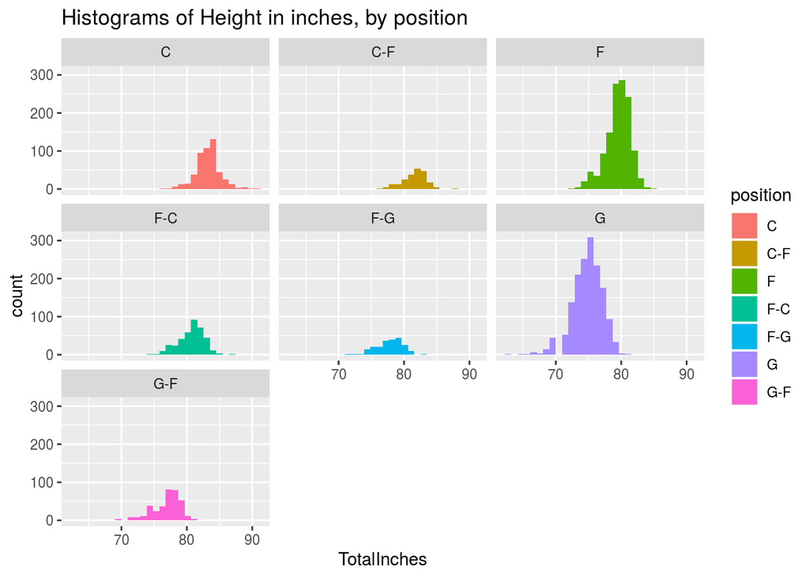

```r
BBall %>% drop_na(TotalInches) %>% ggplot(aes(x=TotalInches,fill=position)) +
  geom_histogram() + facet_wrap(~position) + ggtitle('Histograms of Height in inches, by position')
```

# Part 2

## Get the data, drop observations for which we cannot compute height or weight

```r
fifa_raw <- read.csv(file='FIFA Players.csv')
FIFA <- fifa_raw %>% mutate(htc=as.character(Height)) %>% mutate(wtc=as.character(Weight)) %>%
  mutate (TotalInches = 12*as.numeric(str_extract(htc,"^[:digit:]+")) + as.numeric(str_extract(htc,"[:digit:]+$")) ) %>%
  mutate (TotalPounds = as.numeric(str_extract(wtc,"^[:digit:]+")))
```

## Try a little EDA

Make a plot over all positions, with a smooth trend line

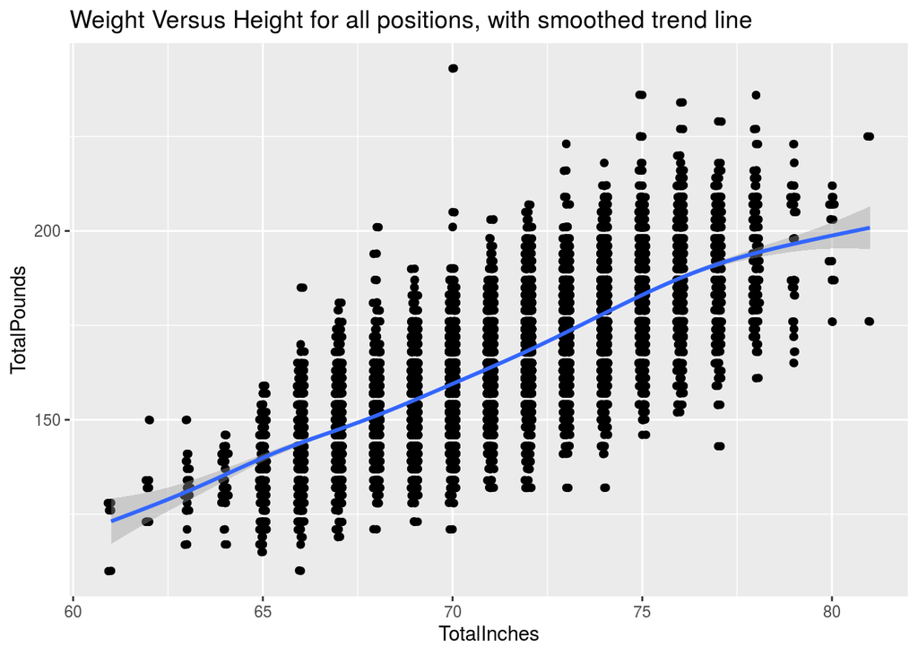

```r
FIFA %>% drop_na(TotalInches) %>% drop_na(TotalPounds) %>% ggplot(aes(x=TotalInches,y=TotalPounds)) + geom_point() + geom_jitter(width=0.1,height=0.1) + geom_smooth() + ggtitle("Weight Versus Height for all positions, with smoothed trend line")
```

Now make separate scatter plots for each position

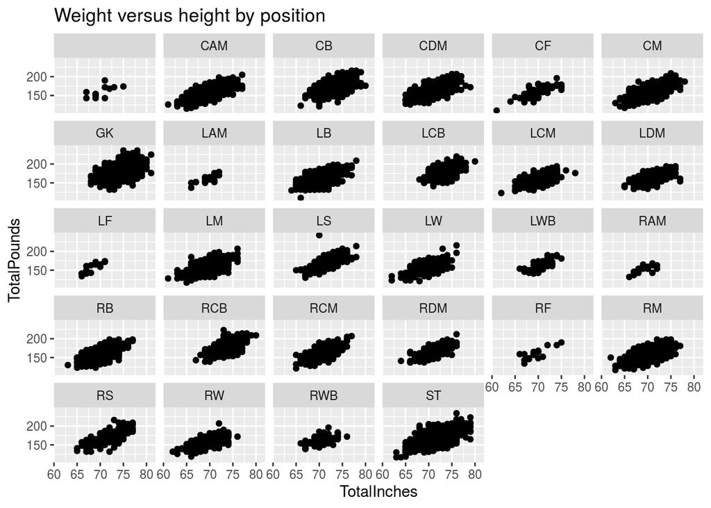

```r
FIFA %>% drop_na(TotalInches) %>% drop_na(TotalPounds) %>% ggplot(aes(x=TotalInches,y=TotalPounds)) + geom_point() + facet_wrap(~Position) + ggtitle("Weight versus height by position")
```

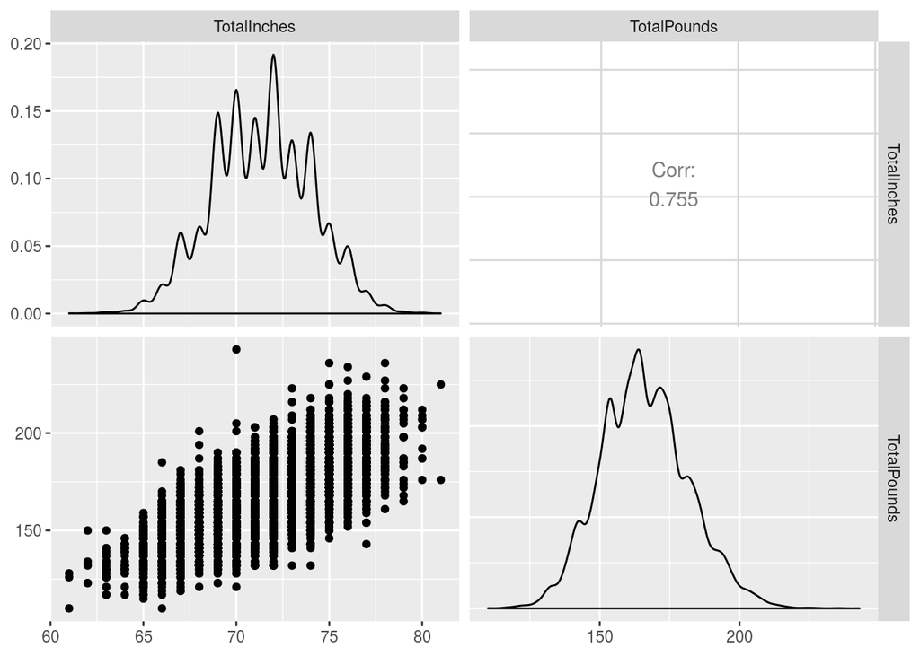

```r
FIFA %>% select(TotalInches,TotalPounds) %>% drop_na(TotalInches) %>% drop_na(TotalPounds) %>% ggpairs()
```

## limit to only LB and LM positions

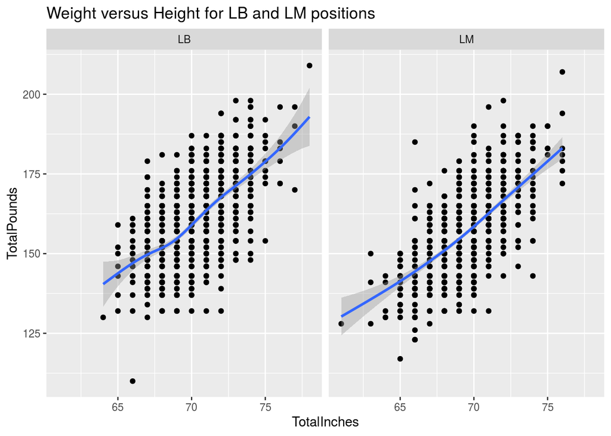

```r
FIFA %>% filter(grepl("(LM|LB)",Position)) %>% drop_na(TotalInches) %>% drop_na(TotalPounds) %>%
  ggplot(aes(x=TotalInches,y=TotalPounds)) + geom_point() + geom_smooth() + facet_wrap(~Position) + ggtitle("Weight versus Height for LB and LM positions")
```

# Part 3

## load the data

```r
df <- read.csv(file='yob2016.txt',header=FALSE,sep=";")
names(df) <- c("name","gender","count")
summary(df)
```

```
##       name       gender        count
##  Aalijah:    2   F:18758   Min.   :    5.0
##  Aaliyan:    2   M:14111   1st Qu.:    7.0
##  Aamari :    2             Median :   12.0
##  Aarian :    2             Mean   :  110.7
##  Aarin  :    2             3rd Qu.:   30.0
##  Aaris  :    2             Max.   :19414.0
##  (Other):32857
```

```r
str(df)
```

```
## 'data.frame':    32869 obs. of  3 variables:
##  $ name  : Factor w/ 30295 levels "Aaban","Aabha",..: 9317 22546 3770 26409 12019 20596 6185 339 9298 11222 ...
##  $ gender: Factor w/ 2 levels "F","M": 1 1 1 1 1 1 1 1 1 1 ...
##  $ count : int  19414 19246 16237 16070 14722 14366 13030 11699 10926 10733 ...
```

## Question 1

```r
bad <- df %>% filter(grepl("yyy$",name,ignore.case = TRUE))
as.character(bad$name)
```

```
## [1] "Fionayyy"
```

```r
dim(df)[1]
```

```
## [1] 32869
```

```r
y2016 <- df %>% filter(!grepl("yyy$",name,ignore.case=TRUE))
dim(y2016)[1]
```

```
## [1] 32868
```

## Question 2

### load the data

```r
y2015 <- read.csv(file='yob2015.txt',header=FALSE,sep=',')
names(y2015) <- c("name","gender","count")
tail(y2015,10)
```

```
##         name gender count
## 33054   Ziyu      M     5
## 33055   Zoel      M     5
## 33056  Zohar      M     5
## 33057 Zolton      M     5
## 33058   Zyah      M     5
## 33059 Zykell      M     5
## 33060 Zyking      M     5
## 33061  Zykir      M     5
## 33062  Zyrus      M     5
## 33063   Zyus      M     5
```

It is interesting to note that the last five names all are male, and that they all have a count of 5.

### join the lists, keeping only names that appear in both years

We want to ignore case, so must change factor to string first, and convert back to Factor after. We also want to handle the combination of gender+name, rather than just name, so that for instance, we handle the male name of Lee separately from the female name of Lee.

```r
tmp2016 <- y2016 %>% mutate(gender.name = tolower(paste(gender,name,sep="."))) %>% select(gender.name,count)
tmp2015 <- y2015 %>% mutate(gender.name = tolower(paste(gender,name,sep="."))) %>% select(gender.name,count)

final <- inner_join(tmp2015,tmp2016,by="gender.name") %>%
  separate(col=gender.name,into=c("gender","name"))

dim(y2015)[1]
```

```
## [1] 33063
```

```r
dim(y2016)[1]
```

```
## [1] 32868
```

```r
dim(final)[1]
```

```
## [1] 26550
```

## Question 3

### total number of children from both years and sort by the total

```r
summed_and_sorted <-  final %>% mutate(Total = count.x + count.y) %>% dplyr::arrange(desc(Total))
```

### top ten names

```r
head(summed_and_sorted,10)
```

```
##    gender     name count.x count.y Total
## 1       f     emma   20415   19414 39829
## 2       f   olivia   19638   19246 38884
## 3       m     noah   19594   19015 38609
## 4       m     liam   18330   18138 36468
## 5       f   sophia   17381   16070 33451
## 6       f      ava   16340   16237 32577
## 7       m    mason   16591   15192 31783
## 8       m  william   15863   15668 31531
## 9       m    jacob   15914   14416 30330
## 10      f isabella   15574   14722 30296
```

### top ten girl names

```r
top_girls <- summed_and_sorted %>% filter(gender == "f") %>% select(name,Total) %>% head(10)
names(top_girls) = c("Name","Count")
top_girls
```

```
##         Name Count
## 1       emma 39829
## 2     olivia 38884
## 3     sophia 33451
## 4        ava 32577
## 5   isabella 30296
## 6        mia 29237
## 7  charlotte 24411
## 8    abigail 24070
## 9      emily 22692
## 10    harper 21016
```

```r
write.csv(top_girls,file="PopularGirlNames.csv",quote=FALSE,row.names=FALSE)
```

## Question 4

I was curious about the relative frequencies of names, and so started out making histograms

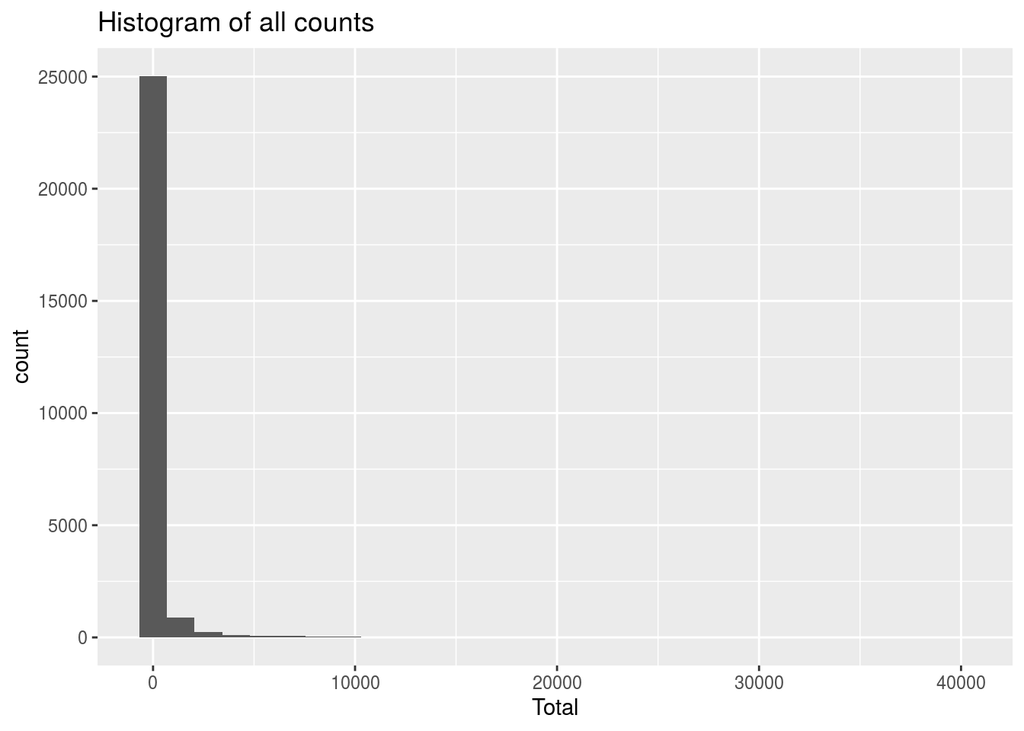

```r
final %>% mutate(Total = count.x + count.y) %>% dplyr::arrange(desc(Total)) %>% arrange(Total) %>%
  ggplot(aes(x=Total)) + geom_histogram() + ggtitle('Histogram of all counts')
```

There are some very common names dominating the distribution, so I dropped the top 100

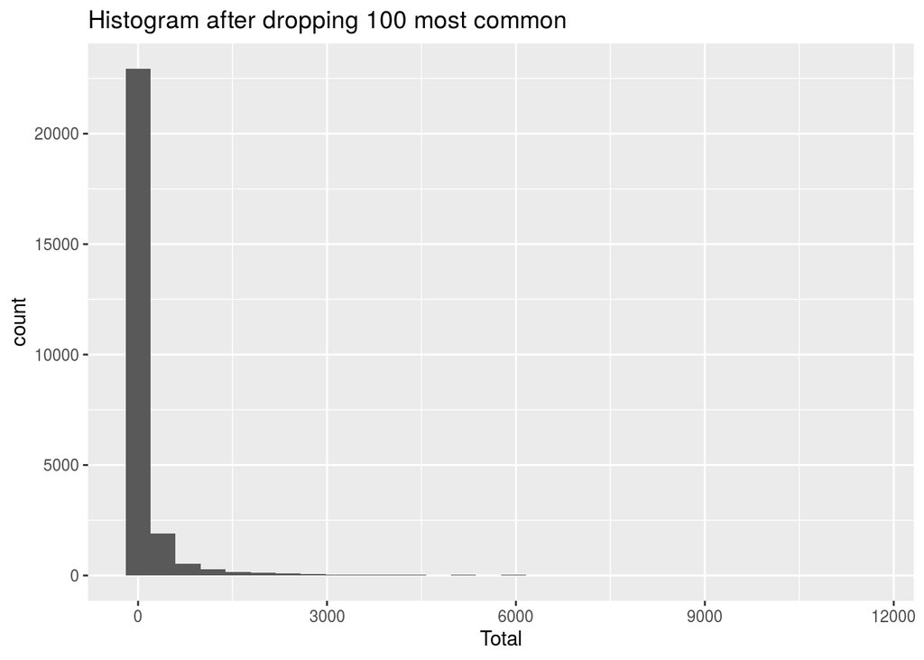

```r
final %>% mutate(Total = count.x + count.y) %>% dplyr::arrange(desc(Total)) %>% arrange(Total) %>% head (-100) %>%
  ggplot(aes(x=Total)) + geom_histogram() + ggtitle('Histogram after dropping 100 most common')
```

The distribution looks very similar

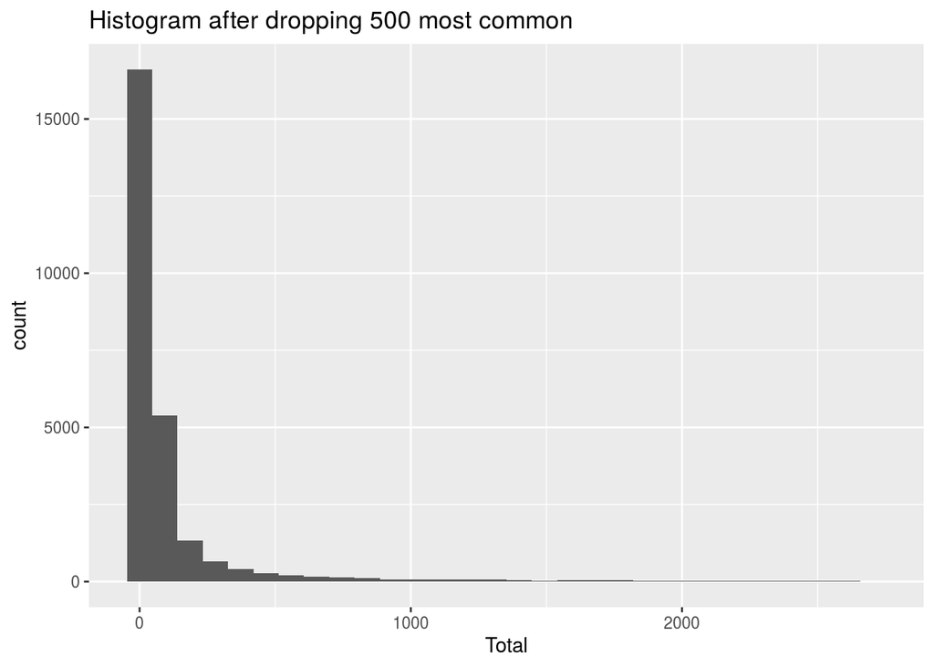

```r
final %>% mutate(Total = count.x + count.y) %>% dplyr::arrange(desc(Total)) %>% arrange(Total) %>% head (-500) %>%
  ggplot(aes(x=Total)) + geom_histogram() + ggtitle('Histogram after dropping 500 most common')
```

So I drop more

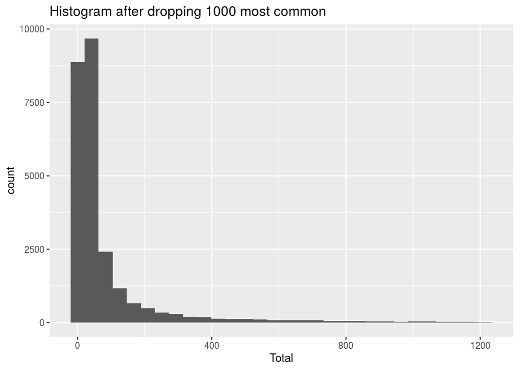

```r
final %>% mutate(Total = count.x + count.y) %>% dplyr::arrange(desc(Total)) %>% arrange(Total) %>% head (-1000) %>%
  ggplot(aes(x=Total)) + geom_histogram() + ggtitle('Histogram after dropping 1000 most common')
```

only when dropping the 5000 most common names

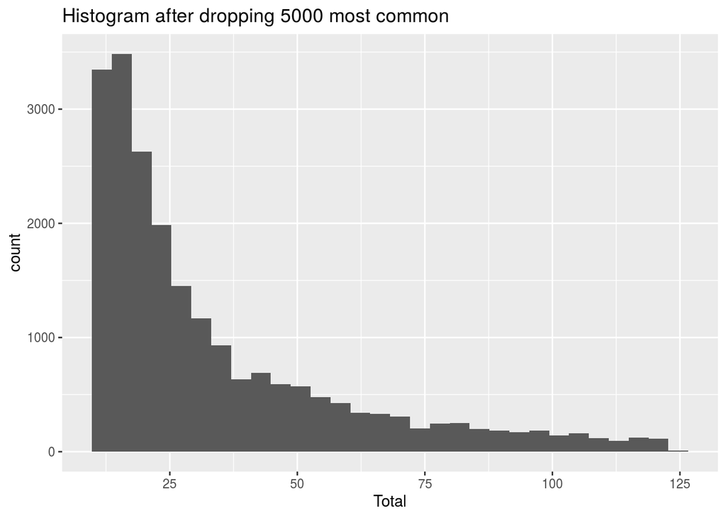

```r
final %>% mutate(Total = count.x + count.y) %>% dplyr::arrange(desc(Total)) %>% arrange(Total) %>% head (-5000) %>%
  ggplot(aes(x=Total)) + geom_histogram() + ggtitle('Histogram after dropping 5000 most common')
```

does a histogram show significant detail in the distribution, and it is still a very skewed distribution.

This behavior is reminiscent of a power law distribution. This is a widely oberved phenomenon in nature. The idea is that the frequency of an event is inversely proportional to its size. Events such as earthquakes follow such a distribution. It is related to fractals, in that the same pattern is apparent at many different scales.

I discovered an R package that can test data to see if it was generated by a power law. It does a ‘goodness of fit’ test, using a bootstrapping procedure, to generate a p-value to test the hypothesis that the data were generated from a power-law distribution.

The package comes with a sample dataset, which is the frequency of unqiue words in the novel ‘Moby Dick’. Here is a basic analysis of that dataset.

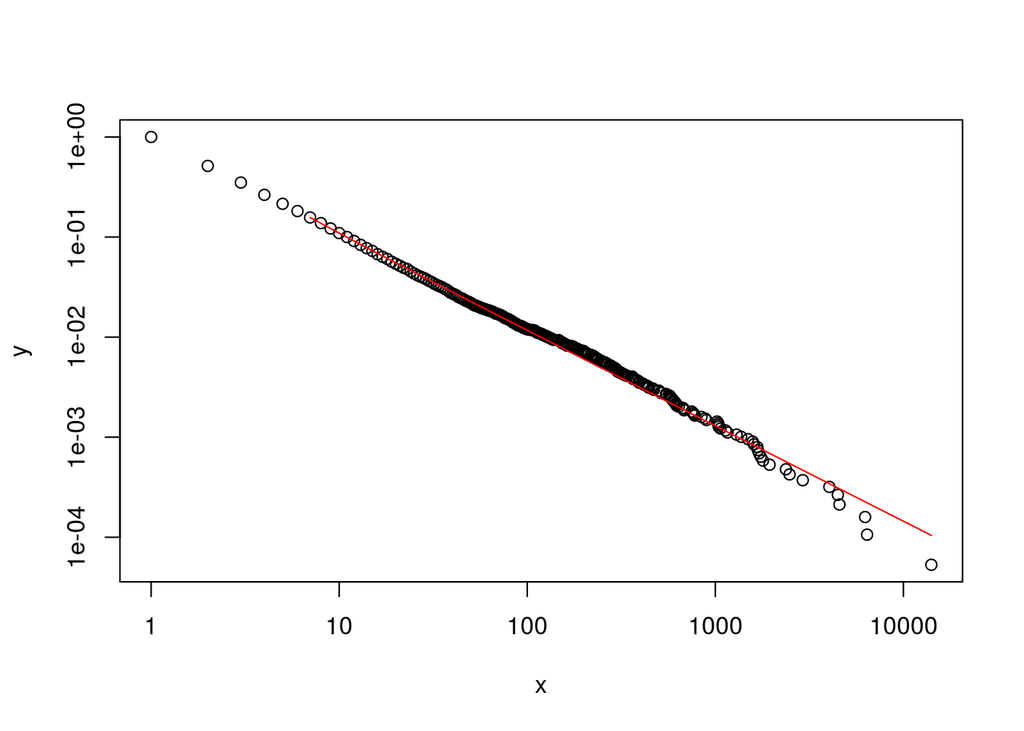

```r
library("poweRlaw")
data("moby",package="poweRlaw")
m_pl <- displ$new(moby)
est <- estimate_xmin(m_pl)
m_pl$setXmin(est)
plot(m_pl)
lines(m_pl,col=2)
```

```r
#m_p <- bootstrap_p(m_pl,no_of_sims=10,threads=4)
#m_p$p
```

Now, to return to baby names, here is the same analysis.

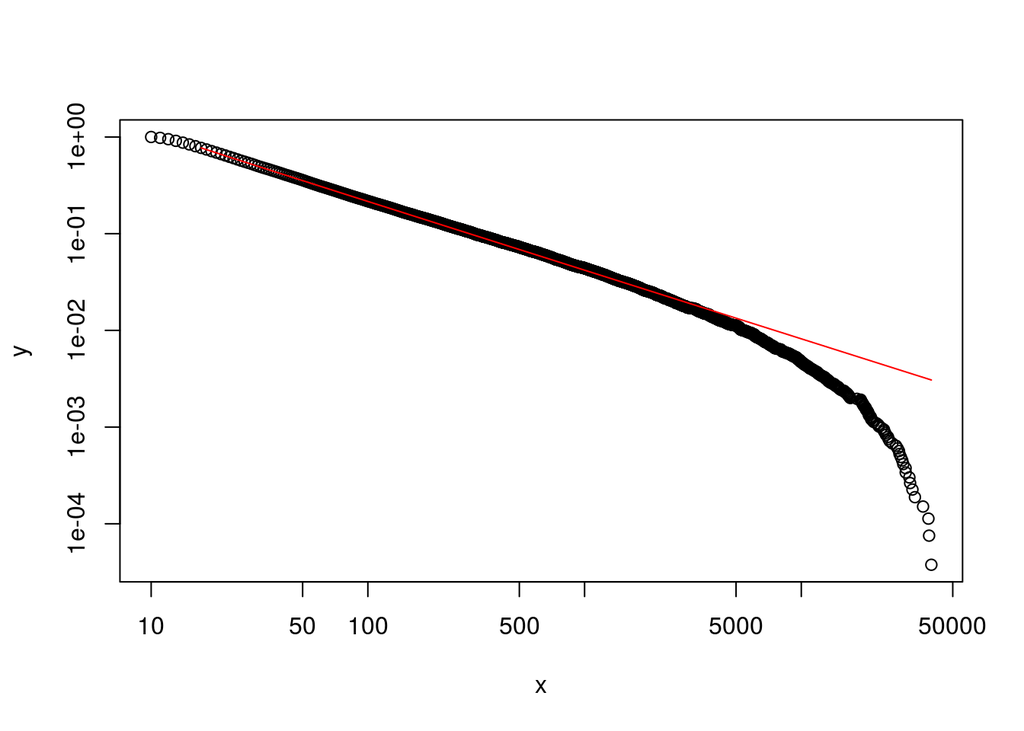

```r
name_counts <- summed_and_sorted$Total
nc_pl <- displ$new(name_counts)
est <- estimate_xmin(nc_pl)
nc_pl$setXmin(est)
plot(nc_pl)
lines(nc_pl,col=2)
```

```r
#nc_p <- bootstrap_p(nc_pl,no_of_sims=10,threads=4)
#nc_p$p
```